# Exploring Food Pantry Data, UTEP (2022)

### Research Question 1

#### How is use of government federal aid/assistance associated with food insecurity as measured by the USDA index or categories?

Below are the bar graphs and the donuts charts to demostrate the different levels of food insecurity among the students receiving various Federal Aids in the year 2022.The graphs are interactive and can be changed to different year from the horizontal year bar.

Among the participants of the survey, 54.7 % of students work and study. Similarly, 28.1% student are getting loans, 12.5% students received scholarship and 4.7% students applied for emergency loans. In every group of students receiving Federal Aid, majority of the students have food insecurity level either very low or low. only few students in each group have marginal food insecurity.Among the students, work study group, there are more number of students with marginal food insecurity.

[interactive chart not shown]

### Research Question 2

#### Does food insecurity (as measured by USDA index or categories) have a relationship with the items pertaining to concentration on school and degree progress/completion?

Graphs below shows the relations between food insecurity, students concentration and the progress towards degree completion.

[interactive chart not shown]

### Research Question 3

#### Are there gender or ethnicity differences in the items pertaining to concentration on school and degree progress/completion?

Graphs below show the relationship between Gender, students concentration and the progress towards degree completion

The number of female students who are delaying graduation are high in number in comparison to other genders. Females who thing almost every day about delaying and delayed in actual are a bit higher in comparison to others.

[interactive chart not shown]

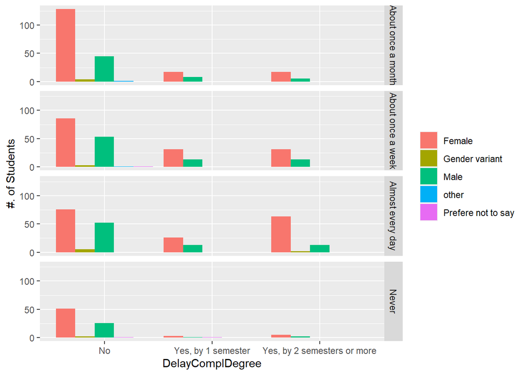